# Obligatorisk øving 2, Maxwell Velocity Distribution

A. Download the file maxwell.zip and "pack out" the 49 txt files. Create a program that:

- Reads in all values for $t$, $x$ and $y$ from the 49 files,
- Calculates $v_{x}$, $v_{y}$ and $v$, a total of 920 of each,
- Plot histogram of the discs' speed distribution $f(v)$ and the discs' distribution of velocity components $g(v_{x})$ and $g(v_{y})$
- Create a scatter plot of $v_{x}$ vs $v_{y}$ and $x$ vs $y$ for all measured values.

B. The plastic discs have mass $m$ = 32 $g$. What will then be the value of "Boltzmann's plastic disc constant" $k_{p}$? That is: Apply the classical equipartition theorem

$$ \frac{1}{2}m〈v^{2}〉=k_{p}T$$

(two independent quadratic contributions to the energy in two dimensions) with $T$ = $300\text{ } K$, and thus determine $k_{p}$. Or vice versa: What temperature would an ambient gas have to have in order to give such plastic discs a velocity distribution as measured in this experiment?

C. Calculate the average speed of the plastic discs $〈v〉$ and compare with the disc's rms speed $v_{rms}=\sqrt{〈v^{2}〉}$. Is the relationship between these as expected, i.e. $\frac{〈v〉}{v_{rms}}=\frac{\sqrt{\pi}}{2}?$

D. Do the scatterplots of velocities and positions give a visual impression roughly as expected? Is it signs of drift in any particular direction? Compare with $〈v_{x}〉$ and $〈v_{y}〉$.

# Part A. Data Visualization

## Imports

- numpy to handle array functions
- pandas handles data using dataframes
- matplotlib.pyplot for plotting data
- Latex to print more visible and clear output
- scipy and math for constants

```python
import matplotlib.pyplot as plt
import numpy as np
import pandas as pd
from IPython.display import Latex
import math
from scipy import constants
```

## Constants

- Boltzmann constant $k_{b}$
- Room temperature $T$ in kelvin
- Mass $M$ of one of the disks used to simulate a particle
- mathematical constants $\pi$ and $e$

```python
KB = constants.Boltzmann
T = 300
M = 0.032
PI = constants.pi
E = math.e
```

### Functions and Maxwell velocity PDF's

$\large v = \sqrt{v_{x}^{2} + v_{y}^{2}} $ $\text{Using pythagorean theorem in the cartesian plane}$

$\large f(v) = 2Bve ^{-Bv^{2}}$ $\text{PDF for the velocity } v$

$\large{g(v_{x})}\text{ }dv_{x} = \sqrt{\frac{B}{\pi}}e ^{-Bv_{x}^{2}}\text{ }dv_{x}$ $\text{PDF for the x component of the velocity } v_{x}$

$\large{g(v_{y})}\text{ }dv_{y} = \sqrt{\frac{B}{\pi}}e ^{-Bv_{y}^{2}}\text{ }dv_{y}$ $\text{PDF for the y component of the velocity } v_{y}$

```python
def velocity(velocity_x, velocity_y):
    return math.sqrt(velocity_x**2 + velocity_y**2)

def f(v, B):
    return 2*B*v*E**(-B*v**2)

def gx(v, D, B):
    return math.sqrt(B/PI)*E**(-B*v**2)

def gy(v, D, B):
    return math.sqrt(B/PI)*E**(-B*v**2)
```

### Process data into dataframe

```python
dfs = []
file_names = [f for f in listdir("/Users/petterstangeland/Documents/Skole NTNU/maxwell")
              if isfile(join("/Users/petterstangeland/Documents/Skole NTNU/maxwell", f))]
for file_name in file_names:
    if file_name[0] == 'm':
        df = pd.read_csv(file_name, sep="\t", header=1)
        dfs.append(df)
df = pd.concat(dfs)
df['x'] = df['x'].apply(lambda x: x * 0.22)
df['y'] = df['y'].apply(lambda x: x * 0.22)


# calculating velocity with respect to the x and y component
#Vx
df['velocity [x]'] = (df['x'].diff() / df['t'].diff())
df['velocity [x]'] = df['velocity [x]'].fillna(0)
#Vy
df['velocity [y]'] = (df['y'].diff() / df['t'].diff())
df['velocity [y]'] = df['velocity [y]'].fillna(0)

df['velocity'] = df.apply(lambda x: velocity(x['velocity [x]'], x['velocity [y]']), axis=1)
df['velocity_measurement_no.'] = np.arange(len(df))
df.replace([np.inf, -np.inf], 0, inplace=True)
df['v_squared'] = df['velocity']**2
df['vx_squared'] = df['velocity [x]']**2
df['vy_squared'] = df['velocity [y]']**2
df.sort_values(by=['t'])
df.head()
```

|  | t | x | y | velocity [x] | velocity [y] | velocity | velocity_measurement_no. | v_squared | vx_squared | vy_squared |
| --- | --- | --- | --- | --- | --- | --- | --- | --- | --- | --- |
| 0 | 13.519 | -34.12574 | -0.80564 | 0.000000 | 0.000000 | 0.000000 | 0 | 0.000000 | 0.000000 | 0.000000 |
| 1 | 13.583 | -30.52346 | 0.04730 | 56.285625 | 13.327187 | 57.841901 | 1 | 3345.685508 | 3168.071582 | 177.613927 |
| 2 | 13.647 | -27.39528 | 0.14212 | 48.877812 | 1.481562 | 48.900262 | 2 | 2391.235582 | 2389.040555 | 2.195027 |
| 3 | 13.727 | -25.78378 | -1.84844 | 20.143750 | -24.882000 | 32.013819 | 3 | 1024.884588 | 405.770664 | 619.113924 |
| 4 | 13.791 | -24.55156 | -3.45994 | 19.253438 | -25.179687 | 31.697185 | 4 | 1004.711518 | 370.694856 | 634.016663 |

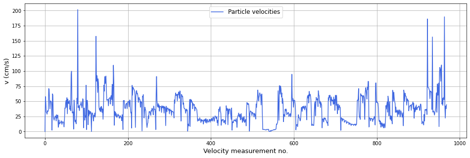

```python
fig, ax = plt.subplots(1, 1, figsize=(16, 5))
x = np.array(df['velocity_measurement_no.'])
y = np.array(df['velocity'])
df.head()

ax.plot(x, y, color='royalblue', label='Particle velocities')
ax.legend(prop={'size': 12}, loc='best')
ax.set_xlabel('Velocity measurement no.', fontsize=13)
ax.set_ylabel('v (cm/s)', fontsize=13)
ax.grid()

plt.show()
```

## Comparison beetween the analytical distributions and observed data

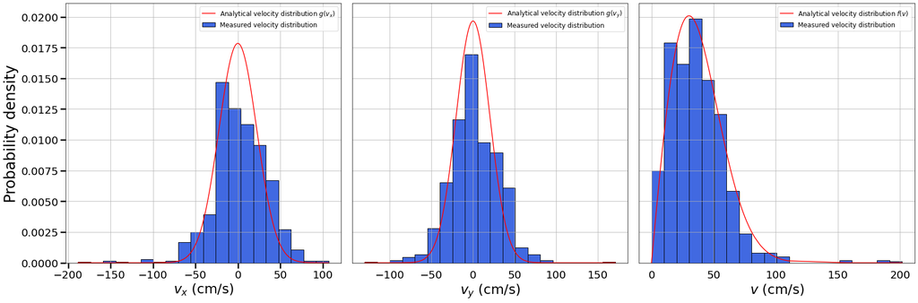

```python
fig, ax = plt.subplots(1, 3, figsize=(24, 8), sharey=True)

#Velocity_x Vx
vxs = [v for v in df['velocity [x]']]
vxs.sort()
Vx_max = df['velocity [x]'].max()
Vx_min = df['velocity [x]'].min()
Dx = (Vx_max - Vx_min) / 20
Bx = 1 / df['vx_squared'].mean()
gx_values = [gx(v, Dx, Bx) for v in vxs]
ax[0].plot(vxs, gx_values, color='r', label='Analytical velocity distribution $g(v_{x})$')
ax[0].hist(df['velocity [x]'], bins=20, density=True, color='royalblue', histtype='bar',
           ec='black', label='Measured velocity distribution')
ax[0].grid()
ax[0].set_xlabel('$v_{x}$ (cm/s)', fontsize=25)
ax[0].set_ylabel('Probability density', fontsize=28)
ax[0].tick_params(axis='both', which='major', labelsize=20, width=2.5, length=10)
ax[0].legend(prop={'size': 12})

#Velocity_y Vy
vys = [v for v in df['velocity [y]']]
vys.sort()
Vy_max = df['velocity [y]'].max()
Vy_min = df['velocity [y]'].min()
Dy = (Vy_max - Vy_min) / 20
By = 1 / df['vy_squared'].mean()
gy_values = [gy(v, Dy, By) for v in vys]
ax[1].plot(vys, gy_values, color='r', label='Analytical velocity distribution $g(v_{y})$')
ax[1].hist(df['velocity [y]'], bins=20, density=True, color='royalblue', histtype='bar',
           ec='black', label='Measured velocity distribution')
ax[1].grid()
ax[1].set_xlabel('$v_{y}$ (cm/s)', fontsize=25)
#ax[1].set_ylabel('probability density', fontsize=20)
ax[1].tick_params(axis='both', which='major', labelsize=20, width=0, length=10)
ax[1].legend(prop={'size': 12})

# Velocity V
Bv = 1 / df['v_squared'].mean()
vs = [v for v in df['velocity']]
vs.sort()
f_values = [f(v, Bv) for v in vs]
ax[2].plot(vs, f_values, color='r', label='Analytical velocity distribution $f(v)$')
ax[2].hist(df['velocity'], bins=20, density=True, color='royalblue', histtype='bar',
           ec='black', label='Measured velocity distribution')
ax[2].grid()
ax[2].set_xlabel('$v$ (cm/s)', fontsize=25)
#ax[2].set_ylabel('probability density', fontsize=20)
ax[2].tick_params(axis='both', which='major', labelsize=20, width=0, length=10)
ax[2].legend(prop={'size': 12})
plt.tight_layout()
plt.show()
```

## Position and velocity map

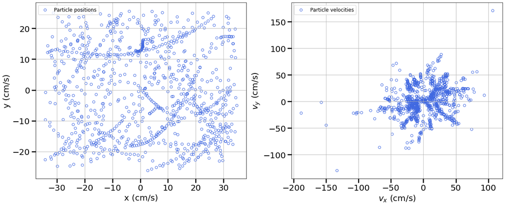

```python
fig, ax = plt.subplots(1, 2, figsize=(17, 7))

ax[0].scatter(x=df['x'], y=df['y'], c='none', edgecolor='royalblue', label='Particle positions')
ax[0].tick_params(axis='both', which='major', labelsize=20, width=2.5, length=10)
ax[0].legend(prop={'size': 12}, loc='upper left')
ax[0].set_xlabel('x (cm/s)', fontsize=20)
ax[0].set_ylabel('y (cm/s)', fontsize=20)
ax[0].grid()

ax[1].scatter(x=df['velocity [x]'], y=df['velocity [y]'], c='none',
              edgecolor='royalblue', label='Particle velocities')
ax[1].tick_params(axis='both', which='major', labelsize=20, width=2.5, length=10)
ax[1].legend(prop={'size': 12}, loc='upper left')
ax[1].set_xlabel('$v_{x}$ (cm/s)', fontsize=20)
ax[1].set_ylabel('$v_{y}$ (cm/s)', fontsize=20)
ax[1].grid()

plt.tight_layout()
plt.show()
```

# Part B. Equipartition theorem

$$\large\frac{1}{2}m〈v^{2}〉=k_{p}T$$$$\large\equiv k_{p}=\frac{1}{2}\frac{m}{T}〈v^{2}〉$$

```python
def equipart_tm(M, T, v_squared_mean):
    return M/(2*T)*v_squared_mean

v = df['v_squared'].mean()
T_approx = 1/3*M/KB*v
print("k_b =", equipart_tm(M, T, v))
print("T_approx =", T_approx)
```

```
k_b = 0.09723587340963742
T_approx = 1.4085531284147876e+24
```

$$\large k_{p} \approx 0.097236$$

If we were to observe these same results from an ambient gas the temperature T would have to be:

$$\large\frac{1}{2}m〈v^{2}〉=\frac{3}{2}k_{b}T$$$$\large\equiv T=\frac{1}{3}\frac{m}{k_{b}}〈v^{2}〉$$$$\large\equiv T \approx 1.4085\cdot10^{24} K$$

# Part C. Velocity relation

$\large\text{We have formulas for } 〈v〉\text{ and } v_{rms} \text{ of the Maxwell velocity distribution in nth-dimensional space given by:} $

$$\large v_{rms}= \Bigg[\frac{nk_{b}T}{M}\Bigg]^{\frac{1}{2}}$$$$\large 〈v〉=\Bigg[\frac{nk_{b}T}{M}\Bigg]^{\frac{1}{2}} \frac{\Gamma(\frac{n+1}{2})}{\Gamma(\frac{n}{2})}$$

$\large\text{In our 2-dimensional case n becomes 2 and we get:} $

$$\large v_{rms}= \Bigg[\frac{2k_{b}T}{M}\Bigg]^{\frac{1}{2}}$$$$\large 〈v〉=\Bigg[\frac{2k_{b}T}{M}\Bigg]^{\frac{1}{2}} \frac{\Gamma(\frac{3}{2})}{\Gamma(1)}$$

$\large\text{Where }\Gamma(1)= 0!= 1 \text{ and } \Gamma(n + 1) = n \Gamma(n)\text{ thus }\Gamma(\frac{3}{2})=\Gamma(\frac{1}{2} + 1)=\frac{1}{2}\Gamma(\frac{1}{2})= \frac{\sqrt{\pi}}{2} $

$$\large\Rightarrow \frac{〈v〉}{v_{rms}}=\frac{\sqrt{\pi}}{2} \approx 0.88623 \land \frac{v_{rms}}{〈v〉}=\frac{2}{\sqrt{\pi}}\approx 1.12838$$

```python
v_mean = df['velocity'].mean()
v_rms = math.sqrt(df['v_squared'].mean())
print("〈v〉 / v_rms = ", v_mean / v_rms)
print("v_rms / 〈v〉 = ", v_rms / v_mean)
```

```
〈v〉 / v_rms =  0.8518932712353593
v_rms / 〈v〉 =  1.1738559673676798
```

$\text{As we expected the results from our observed values are approximatly equal to our expected formulaic result }\frac{〈v〉}{v_{rms}}=\frac{\sqrt{\pi}}{2}$

# Part D. Expectation for velocity and position plot

```python
vx_mean_obs = df['velocity [x]'].mean()
vy_mean_obs = df['velocity [y]'].mean()
print("observed vx mean =", vx_mean_obs, "observed vy mean =", vy_mean_obs)

# Calculating expected discrete value of the analytical PDF's g(vx) and g(vy)
vx_val = [v for v in df['velocity [x]']]
vx_val.sort()
expct_gx_values = [v * gx(v, Dx, Bx) for v in vx_val]


vy_val = [v for v in df['velocity [y]']]
vy_val.sort()
expct_gy_values = [v * gy(v, Dy, By) for v in vy_val]

vx_mean_ana = sum(expct_gx_values)
vy_mean_ana = sum(expct_gy_values)
print("analytical mean vx =", int(vx_mean_ana), "nalytical mean vy =", int(vy_mean_ana))
```

```
observed vx mean = 1.5415730487363808 observed vy mean = 1.827290474821649
analytical mean vx = 0 nalytical mean vy = 0
```

As we can see from the results both $〈v_{x}〉$ and $〈v_{y}〉$ differ a bit from our expected values for $v_{x}$ and $v_{y}$ from the analytical PDF's. However as we can see from our plot earlier the majority of the data excluding outliers is centered around the point $(v_{x}, v_{y}) = (0,0)$ Meaning we can conclude our observed data is quite similar to the analytical expectation.